# Projet Kaggle

Allan Clerc, François Canava, Julien Gaultier, Marco Misseri

2024-04-12

## Introduction

Nous allons étudier un jeu de données portant sur les maladies cardiaques recueillies sur 918 patients. Il contient douze attributs décrivants les symptômes et résultats d’analyses des patients comme l’age, le sexe, le type de douleur thoracique, le taux de cholesterol… Le jeu de données est donné dans le .zip : heart.csv ou : https://www.kaggle.com/datasets/fedesoriano/heart-failure-prediction/data

Objectifs :  
- Etudier les corrélations entre les différents attributs et les cas de crise cardiaque.  
- Classifier et prédire quand un patient est sujet à souffrir d’une crise cardiaque en fonction de plusieurs attributs.

```r
#Bibliotheques
memory.limit(size=24000)
```

```
## [1] Inf
```

```r
library(doParallel)
library(foreach)
library(caret)
library(ada)
```

```r
library(ggplot2)

#Chargement du jeu de données
setwd(".")
data <- read.csv("heart.csv", sep = ",")

# Détecter le nombre de cœurs disponibles
no_cores <- detectCores() - 2  # Garder un cœur libre pour le système

# Enregistrer le backend parallèle à utiliser avec foreach
registerDoParallel(cores = no_cores)
```

## Analyse statistique

Nous allons donc dans un premier temps procéder à une analyse statistique des données que nous possédons. L’objectif est de déterminer quels traits sont plus ou moins importants dans la détection de maladie cardiaque.

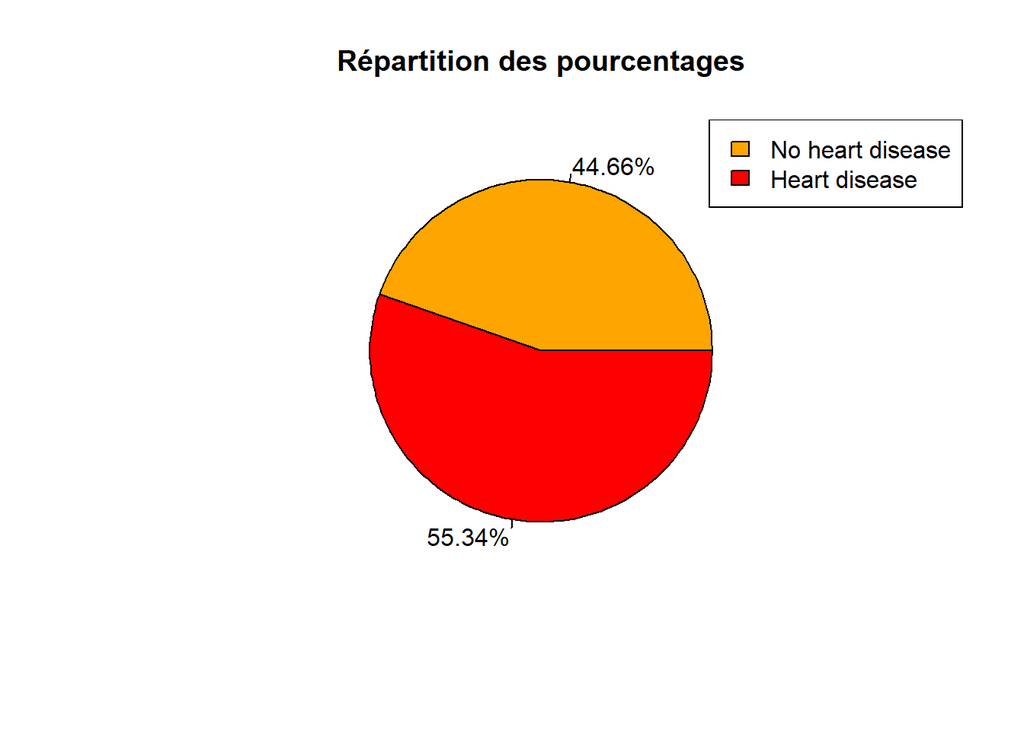

```r
total <- length(data$HeartDisease)
counts <- table(data$HeartDisease)
percentages <- counts / total * 100
labels <- paste0(round(percentages, 2), "%")
pie(percentages, col = c("orange","red"), labels = labels, main = "Répartition des pourcentages")
legend("topright", legend = c("No heart disease", "Heart disease"), fill = c("orange","red"))
```

On note que les données sont plutôt bien réparties entre les patients malades et les sains.